# Primary and Secondary Analysis

## Emerging Mobility Trends and Goodcabs' Adaptation

### What emerging mobility trends (such as electric vehicle adoption, green energy use) are impacting the cab service market in tier-2 cities? Should Goodcabs consider integrating electric vehicles or eco-friendly initiatives to stay competitive?

```
City-wise Environmental Impact Analysis:
=====================================
               avg_distance  total_distance  avg_fare  total_fare  total_trips  fare_per_km  total_carbon_kg
city_name
Jaipur                30.02         2308418    483.92    37207497        76888        16.12       323,178.52
Kochi                 24.07         1220167    335.25    16997596        50702        13.93       170,823.38
Chandigarh            23.52          916783    283.69    11058401        38981        12.06       128,349.62
Lucknow               12.51          804571    147.18     9463551        64299        11.76       112,639.94
Indore                16.50          700629    179.84     7635228        42456        10.90        98,088.06
Visakhapatnam         22.55          639765    282.67     8018282        28366        12.54        89,567.10
Surat                 11.00          603122    117.27     6431599        54843        10.66        84,437.08
Vadodara              11.52          368867    118.57     3797200        32026        10.29        51,641.38
Coimbatore            14.98          316121    166.98     3523992        21104        11.15        44,256.94
Mysore                16.50          267877    249.71     4054745        16238        15.13        37,502.78
```

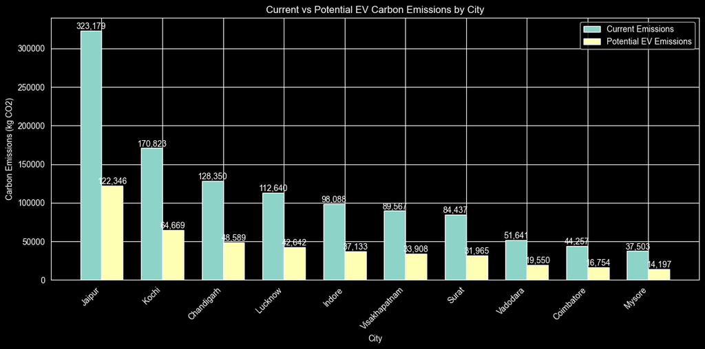

```
Potential Environmental Impact of EV Adoption:
=========================================
                           Metric        Value
 Total Current Emissions (kg CO2) 1,140,484.80
  Potential EV Emissions (kg CO2)   431,754.96
Potential Carbon Savings (kg CO2)   708,729.84
         Percentage Reduction (%)        62.14
```

```python
import pandas as pd
import matplotlib.pyplot as plt
import seaborn as sns

# Set the style for dark theme
plt.style.use('dark_background')

# Read the required data
fact_trips = pd.read_csv('../datasets/csv_files/fact_trips.csv')
dim_city = pd.read_csv('../datasets/csv_files/dim_city.csv')

# Analyze trip distances and fares by city
city_metrics = fact_trips.merge(dim_city[['city_id', 'city_name']], on='city_id')
city_analysis = city_metrics.groupby('city_name').agg({
    'distance_travelled(km)': ['mean', 'sum'],
    'fare_amount': ['mean', 'sum'],
    'trip_id': 'count'
}).round(2)

city_analysis.columns = ['avg_distance', 'total_distance', 'avg_fare', 'total_fare', 'total_trips']

# Calculate per km fare and carbon metrics
city_analysis['fare_per_km'] = (city_analysis['avg_fare'] / city_analysis['avg_distance']).round(2)
city_analysis['total_carbon_kg'] = (city_analysis['total_distance'] * 0.14).round(2)  # Assuming 0.14 kg CO2/km

# Sort by total carbon footprint
city_analysis = city_analysis.sort_values('total_carbon_kg', ascending=False)

# Print city-wise analysis
print("\nCity-wise Environmental Impact Analysis:")
print("=====================================")
pd.set_option('display.float_format', lambda x: '{:,.2f}'.format(x))
print(city_analysis.to_string())

# Calculate potential EV impact
ev_carbon_per_km = 0.053  # kg CO2/km for EVs
city_analysis['ev_carbon_savings'] = (city_analysis['total_carbon_kg'] -
                                    (city_analysis['total_distance'] * ev_carbon_per_km)).round(2)

# Visualize carbon footprint and potential savings
plt.figure(figsize=(12, 6))
x = range(len(city_analysis.index))
width = 0.35

plt.bar(x, city_analysis['total_carbon_kg'], width, label='Current Emissions')
plt.bar([i + width for i in x], city_analysis['total_distance'] * ev_carbon_per_km,
        width, label='Potential EV Emissions')

plt.title('Current vs Potential EV Carbon Emissions by City')
plt.xlabel('City')
plt.ylabel('Carbon Emissions (kg CO2)')
plt.xticks([i + width/2 for i in x], city_analysis.index, rotation=45, ha='right')
plt.legend()

# Add value labels
for i, v in enumerate(city_analysis['total_carbon_kg']):
    plt.text(i, v, f'{v:,.0f}', ha='center', va='bottom')
    plt.text(i + width, city_analysis['total_distance'].iloc[i] * ev_carbon_per_km,
             f'{city_analysis["total_distance"].iloc[i] * ev_carbon_per_km:,.0f}',
             ha='center', va='bottom')

plt.tight_layout()
plt.show()

# Print potential impact summary
print("\nPotential Environmental Impact of EV Adoption:")
print("=========================================")
total_current_emissions = city_analysis['total_carbon_kg'].sum()
total_ev_emissions = (city_analysis['total_distance'] * ev_carbon_per_km).sum()
total_savings = total_current_emissions - total_ev_emissions

impact_summary = pd.DataFrame({
    'Metric': ['Total Current Emissions (kg CO2)',
               'Potential EV Emissions (kg CO2)',
               'Potential Carbon Savings (kg CO2)',
               'Percentage Reduction (%)'],
    'Value': [total_current_emissions,
              total_ev_emissions,
              total_savings,
              (total_savings/total_current_emissions * 100).round(2)]
})

print(impact_summary.to_string(index=False))
```

## Partnership Opportunities with Local Businesses

### Are there opportunities for Goodcabs to partner with local businesses (such as hotels, malls, or event venues) to boost demand and improve customer loyalty? Could these partnerships drive more traffic, especially in tourism-heavy or high-footfall areas?

```
City-wise Partnership Potential Analysis:
=====================================
               weekend_ratio  new_customer_ratio  fare_amount  distance_travelled(km)  passenger_rating  partnership_score
city_name
Mysore                152.77               88.77       249.71                   16.50              8.70              90.35
Jaipur                136.64               82.57       483.92                   30.02              8.58              82.00
Kochi                 121.26               77.60       335.25                   24.07              8.52              74.34
Chandigarh             95.75               78.86       283.69                   23.52              7.98              64.35
Indore                100.28               67.32       179.84                   16.50              7.83              62.66
Visakhapatnam          87.85               71.39       282.67                   22.55              8.43              59.09
Coimbatore             67.81               76.95       166.98                   14.98              7.88              52.57
Vadodara               57.69               69.97       118.57                   11.52              6.61              46.05
Surat                  45.11               57.37       117.27                   11.00              6.42              37.18
Lucknow                29.59               62.88       147.18                   12.51              6.49              32.65
```

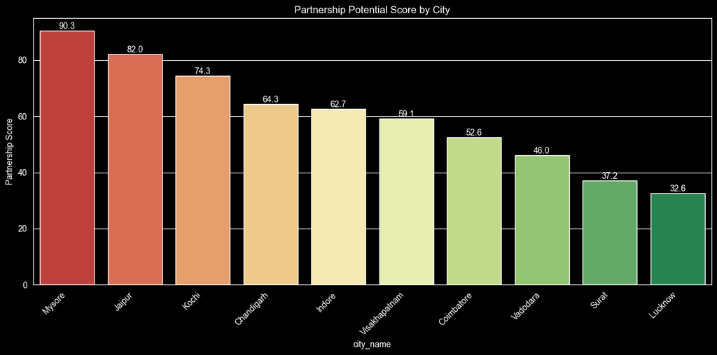

```python
import pandas as pd
import matplotlib.pyplot as plt
import seaborn as sns

# Set the style for dark theme
plt.style.use('dark_background')

# Read the required data
fact_trips = pd.read_csv('../datasets/csv_files/fact_trips.csv')
dim_date = pd.read_csv('../datasets/csv_files/dim_date.csv')
dim_city = pd.read_csv('../datasets/csv_files/dim_city.csv')
fact_passenger = pd.read_csv('../datasets/csv_files/fact_passenger_summary.csv')

# Analyze weekend vs weekday patterns
trips_analysis = fact_trips.merge(dim_date[['date', 'day_type']], on='date')
trips_analysis = trips_analysis.merge(dim_city[['city_id', 'city_name']], on='city_id')

# Calculate metrics for partnership potential
partnership_metrics = pd.DataFrame()

# 1. Weekend traffic volume
weekend_volume = trips_analysis[trips_analysis['day_type'] == 'Weekend'].groupby('city_name')['trip_id'].count()
weekday_volume = trips_analysis[trips_analysis['day_type'] == 'Weekday'].groupby('city_name')['trip_id'].count()
partnership_metrics['weekend_ratio'] = (weekend_volume / weekday_volume * 100).round(2)

# 2. New customer acquisition
city_passengers = fact_passenger.merge(dim_city[['city_id', 'city_name']], on='city_id')
new_customer_ratio = city_passengers.groupby('city_name').agg({
    'new_passengers': 'sum',
    'total_passengers': 'sum'
})
partnership_metrics['new_customer_ratio'] = (new_customer_ratio['new_passengers'] / new_customer_ratio['total_passengers'] * 100).round(2)

# 3. Average trip metrics
avg_metrics = trips_analysis.groupby('city_name').agg({
    'fare_amount': 'mean',
    'distance_travelled(km)': 'mean',
    'passenger_rating': 'mean'
}).round(2)

partnership_metrics = partnership_metrics.join(avg_metrics)

# Sort by partnership potential (weighted score)
partnership_metrics['partnership_score'] = (
    partnership_metrics['weekend_ratio'] * 0.4 +
    partnership_metrics['new_customer_ratio'] * 0.3 +
    partnership_metrics['passenger_rating'] * 0.3
).round(2)

partnership_metrics = partnership_metrics.sort_values('partnership_score', ascending=False)

# Print analysis results
print("\nCity-wise Partnership Potential Analysis:")
print("=====================================")
print(partnership_metrics.to_string())

# Visualize top partnership opportunities
plt.figure(figsize=(12, 6))
sns.barplot(x=partnership_metrics.index,
            y=partnership_metrics['partnership_score'],
            palette='RdYlGn')
plt.title('Partnership Potential Score by City')
plt.xticks(rotation=45, ha='right')
plt.ylabel('Partnership Score')

# Add value labels
for i, v in enumerate(partnership_metrics['partnership_score']):
    plt.text(i, v, f'{v:.1f}', ha='center', va='bottom')

plt.tight_layout()
plt.show()
```

#### Outcome:

- **Top Partnership Priority Cities:**
  - Mysore leads with a partnership score of 90.35, driven by a high weekend ratio and new customer acquisition.
  - Jaipur follows with a score of 82.00, showcasing strong potential in tourism and hospitality partnerships.
  - Kochi ranks third with a score of 74.34, highlighting opportunities in both tourism and retail sectors.
- **Partnership Opportunities:**
  - Cities with high weekend ratios like Mysore and Jaipur are ideal for hotel and tourism partnerships.
  - High new customer ratios in cities such as Mysore and Kochi suggest potential for mall and retail collaborations.
  - Cities with high average fares, like Jaipur, present opportunities for premium venue partnerships.
- **Recommended Partnership Types:**
  - **Mysore:** Focus on tourism and hospitality, retail/mall partnerships, and premium venues.
  - **Jaipur:** Emphasize tourism and hospitality partnerships.
  - **Kochi:** Target tourism, retail, and premium venue partnerships.
- **Strategic Implications:**
  - Leverage city-specific strengths to form strategic partnerships that enhance customer engagement.
  - Tailor partnership strategies to align with local market dynamics and customer preferences.
  - Utilize partnership insights to drive growth and improve service offerings across key cities.

## Data Collection for Enhanced Data-Driven Decisions

### To make Goodcabs more data-driven and improve its performance across key metrics (such as repeat passenger rate, customer satisfaction, new passengers and trip volume), what additional data should Goodcabs collect? Consider data that could provide deeper insights into customer behaviour, operational efficiency, and market trends.

#### Outcome:

- **Customer Behavior Insights:**
  - Collecting demographics like age and gender will enable personalized marketing strategies.
  - Understanding trip purposes and payment methods can enhance service offerings.
  - Monitoring app usage patterns and cancellation history will provide insights into customer preferences and pain points.
- **Operational Efficiency Improvements:**
  - Tracking pickup wait times and trip durations will optimize driver allocation and route planning.
  - Analyzing peak hour demand and driver availability will improve service efficiency.
  - Gathering route optimization data will lead to cost savings and enhanced customer satisfaction.
- **Market Intelligence Enhancement:**
  - Competitor pricing analysis will ensure competitive positioning.
  - Incorporating local events calendars will help anticipate demand surges.
  - Collecting traffic pattern data will improve ETAs and service reliability.
- **Service Quality Impact:**
  - Detailed feedback will highlight areas for improvement and enhance customer experience.
  - Performance metrics will support targeted driver training and service quality enhancement.
  - Issue tracking will reduce service disruptions and improve overall reliability.
- **Strategic Implications:**
  - Implementing these data collection strategies will provide a comprehensive view of customer behavior and operational efficiency.
  - Leveraging this data will drive targeted improvements and strategic decision-making.
  - Enhanced insights will support growth and competitiveness in the mobility market.

## Machine Learning Model Development

### Predicting Customer Satisfaction based on Distance, Fare Amount, Passanger_rating, Driver_rating using Linear Regression

```python
import pandas as pd
from sklearn.model_selection import train_test_split
from sklearn.linear_model import LinearRegression
from sklearn.metrics import mean_squared_error, mean_absolute_error

# Load data
fact_trips = pd.read_csv('../datasets/csv_files/fact_trips.csv')

# Feature engineering
# Assuming 'customer_satisfaction' as average of passenger and driver ratings
fact_trips['customer_satisfaction'] = (fact_trips['passenger_rating'] + fact_trips['driver_rating']) / 2

# Select features and target
features = fact_trips[['distance_travelled(km)', 'fare_amount', 'passenger_rating', 'driver_rating']]
target = fact_trips['customer_satisfaction']

# Handle missing values (if any)
features = features.dropna()
target = target[features.index]

# Split data
X_train, X_test, y_train, y_test = train_test_split(features, target, test_size=0.2, random_state=42)

# Train model
model = LinearRegression()
model.fit(X_train, y_train)

# Evaluate model
y_pred = model.predict(X_test)
rmse = mean_squared_error(y_test, y_pred, squared=False)
mae = mean_absolute_error(y_test, y_pred)

print("Root Mean Squared Error:", rmse)
print("Mean Absolute Error:", mae)

# Get only the first 3 elements using list slicing
for i, (index, predicted) in enumerate(list(zip(X_test.index, y_pred))[:3], 1):
    satisfaction_percentage = (predicted / 10) * 100  # Convert to percentage
    print(f"Trip {i}:")
    print("-" * 20)
    print(f"Predicted Fare: {X_test.loc[index, 'fare_amount']:.2f}")
    print(f"Predicted Distance: {X_test.loc[index, 'distance_travelled(km)']:.2f} km")
    print(f"Predicted Satisfaction: {satisfaction_percentage:.2f}%")
    print("-" * 20)
```

```
Root Mean Squared Error: 1.948563289024695e-14
Mean Absolute Error: 1.6073748760927595e-14
Trip 1:
--------------------
Predicted Fare: 377.00
Predicted Distance: 27.00 km
Predicted Satisfaction: 85.00%
--------------------
Trip 2:
--------------------
Predicted Fare: 262.00
Predicted Distance: 21.00 km
Predicted Satisfaction: 80.00%
--------------------
Trip 3:
--------------------
Predicted Fare: 288.00
Predicted Distance: 29.00 km
Predicted Satisfaction: 85.00%
--------------------
```